# Tugas Praktikum 5 MPDW

Luthfia Aiman Hanin (G1401231064)

# **Library**

```r
library(ggplot2)
library(tsibble)
library(tseries)
library(MASS)
```

# **Menyiapkan Data**

```r
# Baca data
gold <- rio::import("https://raw.githubusercontent.com/shafifaris/MPDW/main/Pertemuan%201/Copy%20of%20Gold%20Price(1).xlsx")

# Ambil subset baris 301-400
gold_sub <- gold[301:400, ]

# Bagi data
train <- gold_sub[1:80, ]
test  <- gold_sub[81:100, ]
```

```r
dt_gold <- ts(gold_sub$Price)
train_gold <- ts(train$Price)
test_gold  <- ts(test$Price)
```

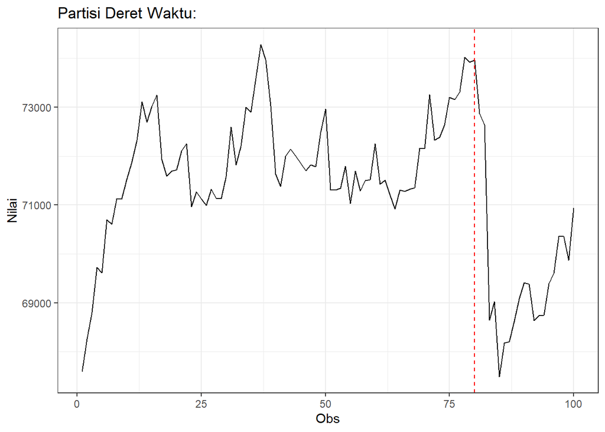

```r
plot_gold <- dt_gold |>
  as_tsibble() |>
  ggplot(aes(x = index, y = value)) +
  geom_line() +
  theme_bw() +
  xlab("Obs") +
  ylab("Nilai") +

  # Tambahkan garis batas
  geom_vline(xintercept = 80, linetype = "dashed", color = "red") +
  ggtitle("Partisi Deret Waktu:")

plot_gold
```

Data dipartisi dengan **proporsi 80:20** untuk data latih dan data uji agar memberikan cukup data untuk melatih model dan data uji yang mamadai untuk mengevaluasi kinerja. Meskipun tren terlihat mulai naik setelah data ke-85, dengan 20% data uji ini bisa benar-benar melihat apakah model tangguh menghadapi pola baru.

# **Eksplorasi**

## **Plot Time Series**

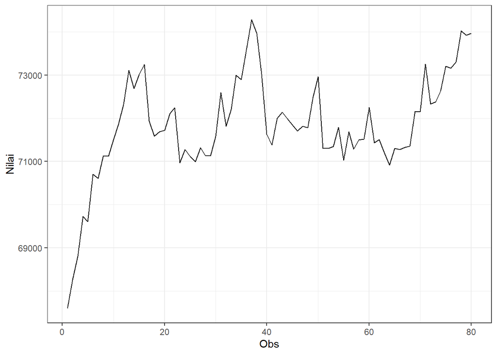

```r
train_gold |> as_tsibble() |>
  ggplot(aes(x = index, y = value)) +
  geom_line() + theme_bw() +
  xlab("Obs") + ylab("Nilai")
```

```r
mean(train_gold)
```

```
## [1] 71839.66
```

```r
var(train_gold)
```

```
## [1] 1407883
```

Berdasarkan plot time series tersebut, terlihat bahwa data tidak stasioner dalam rataan, ditandai dengan adanya kecenderungan tren yang naik di awal, tetapi stasioner dalam ragam karena besarnya fluktuasi relatif konstan.

## **Plot ACF**

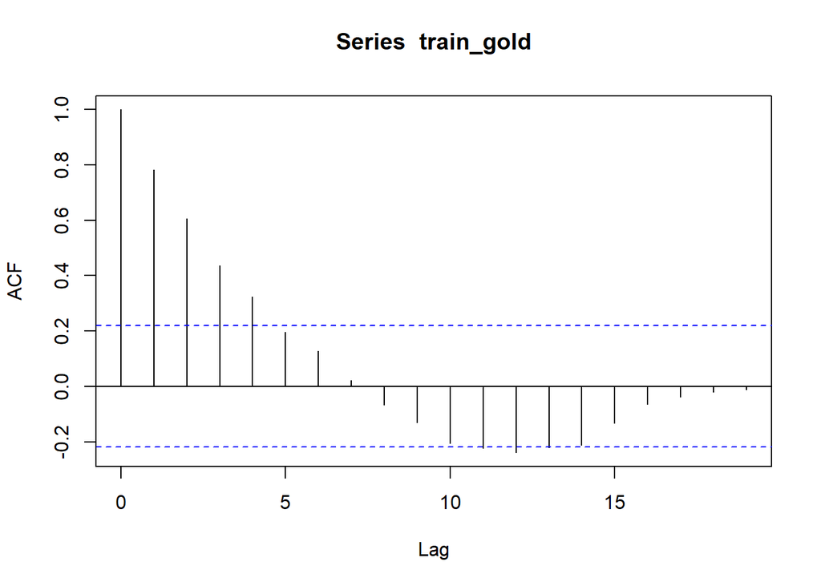

```r
acf(train_gold)
```

Berdasarkan plot ACF tersebut terlihat bahwa plot ACF cenderung menunjukkan korelasi yang menurun secara perlahan pada banyak lag, sehingga menjadi indikasi bahwa data latih tidak stasioner dalam rataan.

## **Uji ADF**

```r
tseries::adf.test(train_gold)
```

```
##
##  Augmented Dickey-Fuller Test
##
## data:  train_gold
## Dickey-Fuller = -3.0861, Lag order = 4, p-value = 0.1313
## alternative hypothesis: stationary
```

**Hipotesis**  
$H_0$: Data tidak stasioner dalam rataan  
$H_1$: Data stasioner dalam rataan

**Interpretasi**  
Dari hasil uji ADF dengan menggunakan Dickey-Fuller Test didapatkan nilai p-value sebesar **0,1313** yang lebih besar daripada $\alpha$ = 0,05. Artinya, **data tidak stasioner dalam rataan**. Hal ini sejalan dengan hasil dari Plot ACF dan grafik time series.

## **Plot Box-Cox**

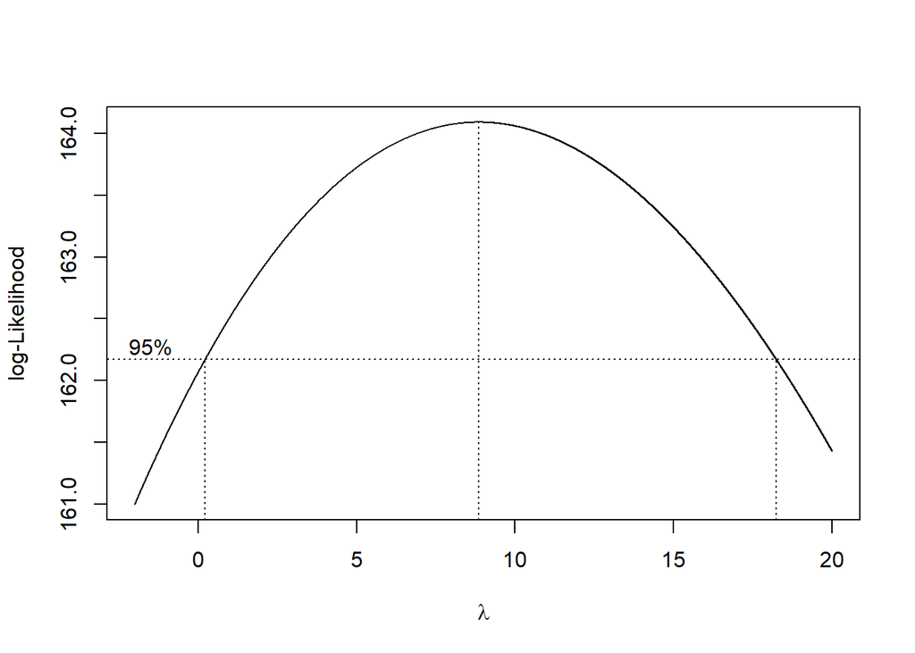

```r
index <- seq(1, 80)

# Uji Box-Cox
bc <- boxcox(
  train_gold ~ index,
  lambda = seq(-2, 20, by = 0.001)
)
```

```r
# Nilai lambda optimum
lambda <- bc$x[which.max(bc$y)]
lambda
```

```
## [1] 8.848
```

```r
# Selang kepercayaan 95% untuk lambda
ci_lambda <- bc$x[bc$y > max(bc$y) - 0.5 * qchisq(0.95, 1)]

# Batas bawah dan batas atas
ci_lower <- min(ci_lambda)
ci_upper <- max(ci_lambda)

c(Batas_Bawah = ci_lower, Batas_Atas = ci_upper)
```

```
## Batas_Bawah  Batas_Atas
##       0.218      18.245
```

Dari plot Box-Cox di atas didapatkan nilai *rounded value* ($\lambda$) sebesar **8,848** dan pada selang kepercayaan 95% nilai memiliki batas bawah **0,218** dan batas atas **18,245**. Selang tersebut memuat nilai satu sehingga dapat dikatakan bahwa **data stasioner dalam ragam**.

Karena dari hasil eksplorasi dengan plot ACF dan uji ADF ditemukan bahwa data latih tidak stasioner dalam rataan, maka selanjutnya **akan dilakukan differencing dengan d = 1** untuk untuk memperoleh sifat stasioneritas dalam rataan.

# **Penanganan Stasioneritas Rataan**

## **Differencing**

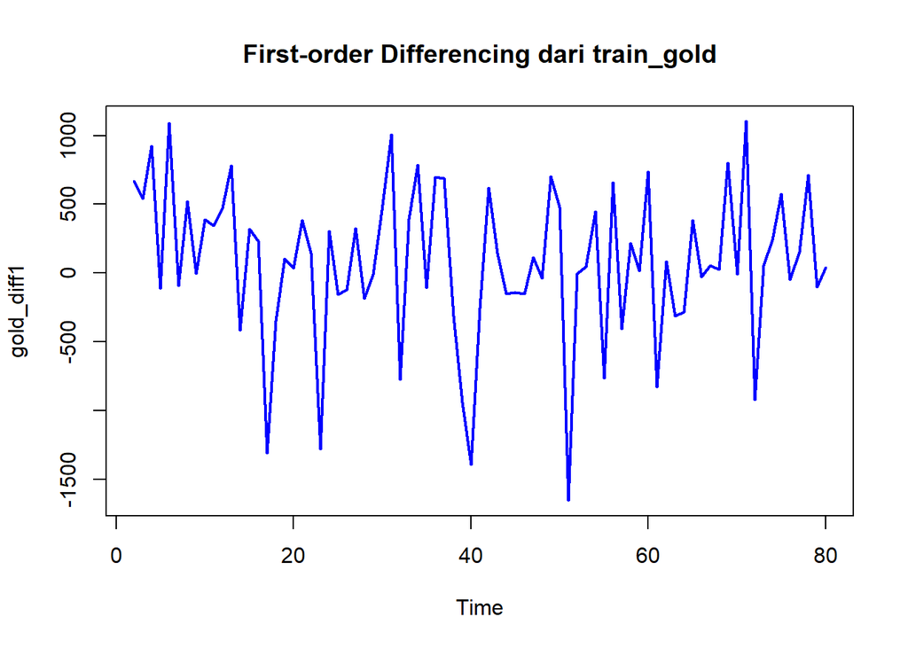

```r
# Differencing pertama pada postrend
gold_diff1 <- diff(train_gold, differences = 1)

# Plot hasil differencing
ts.plot(gold_diff1,
        main = "First-order Differencing dari train_gold",
        col = "blue", lwd = 2)
```

## **Plot ACF**

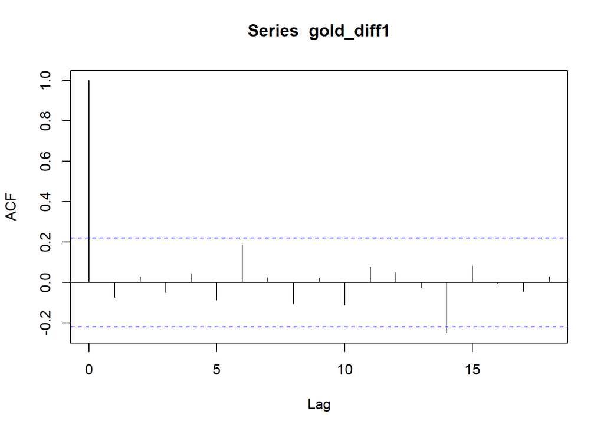

```r
acf(gold_diff1)
```

Pada plot ACF setelah dilakukan *differencing*, hampir semua lag berada dalam batas signifikansi. Hal ini menjadi indikasi bahwa data latih sudah stasioner dalam rataan.

## **Uji ADF**

```r
adf.test(gold_diff1)
```

```
##
##  Augmented Dickey-Fuller Test
##
## data:  gold_diff1
## Dickey-Fuller = -4.4749, Lag order = 4, p-value = 0.01
## alternative hypothesis: stationary
```

Hasil uji ADF dengan menggunakan Dickey-Fuller Test setelah dilakukan *differencing* menghasilkan nilai *p-value* sebesar **0,01** yang lebih kecil daripada $\alpha$ = 0,05. Artinya, **data sudah stasioner dalam rataan**. Hal ini sejalan dengan hasil dari Plot ACF.